# Final STA141A Report

```
##       CP      LSc      LSr      MOp       PT     root
## 1.541818 1.347222 0.500000 1.480984 1.688889 1.000000
```

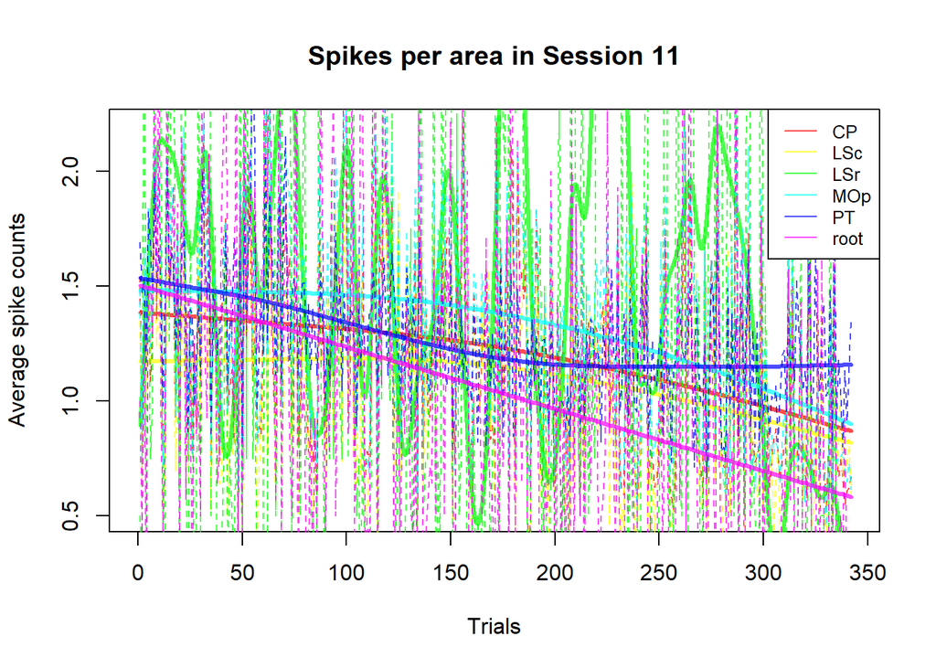

MOp that’s a primary somatomotor area that is essentially in charge of movement

PT is a prelimbic area that is heavily correlated to avoidance and reward-seeking

root spike level average is 1.000, which is the lowest amount among all mice in the dataframe.

```
##       CA3       LGd        MB       SSp       SSs        TH
## 1.0952381 0.9726027 1.2597403 0.9583333 0.7083333 1.4654088
```

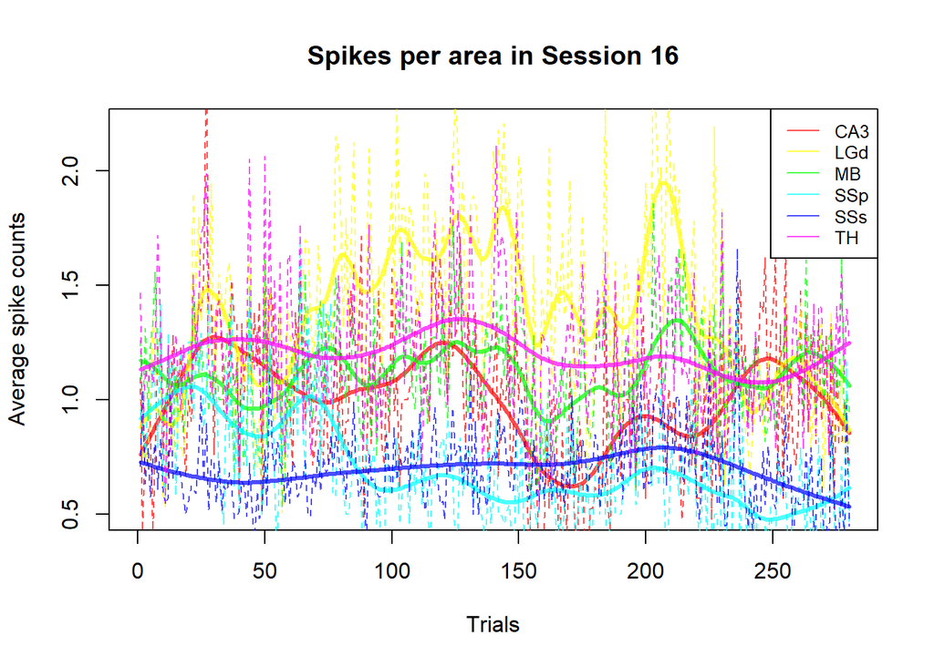

```
##       LD      MEA     root       RT      VPL      VPM
## 4.166667 0.902439 1.072626 1.750000 1.660000 1.100000
```

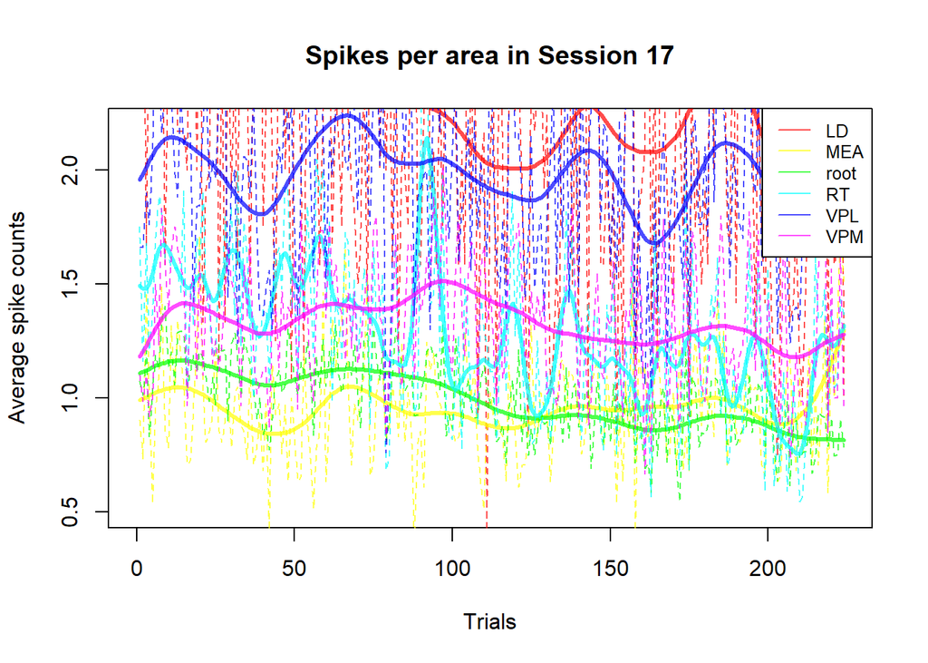

This is a similar to the observation of a previous mouse in that the root level of the neurological activity of the animal is significantly below the amount of 1.6, see across the first two mice observed.

The final brain areas I chose based on overlap (especially between female mice) for my prediction model are:

- root
- CA1
- SSp
- LD

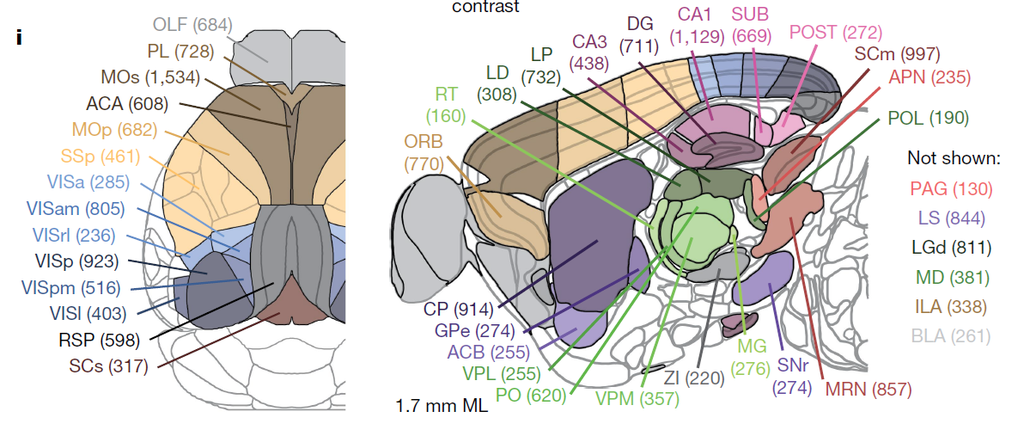

I am including this figure from the original publication to visualize the areas of interest and connect them to a real-world mouse brain, rather that a list of empty letters.

### Data Integration

This method relies on selecting a number (k) of nearest neighbors, then finding the Euclidean distance between the observations and KKN, and figuring out an optimal amount of KNN to apply for the model to give us the closest results possible. I used specifically the Elbow method that reiterated through the Nearest Neighbors in order to pin point the best amount.

I am limited widely due to my lack of skill and experience using R (my first course actually coding) to create the perfect data frame of each session, its averaged spikes to brain areas (ones I depicted above) and gender of the mice to create the perfect model.

```
## k-Nearest Neighbors
##
## 4066 samples
##    5 predictor
##    2 classes: '-1', '1'
##
## No pre-processing
## Resampling: Cross-Validated (10 fold, repeated 3 times)
## Summary of sample sizes: 3659, 3660, 3660, 3659, 3659, 3659, ...
## Resampling results across tuning parameters:
##
##   k  Accuracy   Kappa
##   5  0.7002782  0.1342019
##   7  0.7006042  0.1192270
##   9  0.7033934  0.1163725
##
## Accuracy was used to select the optimal model using the largest value.
## The final value used for the model was k = 9.
```

It’s displayed by the summary of my model that the K-value that is the most optimal for my model in k=9, with accuracy of 70.34% and kappa score at the lowest of 11.64%. Below is a visual depiction of the optimal, best value of KNN to chose.

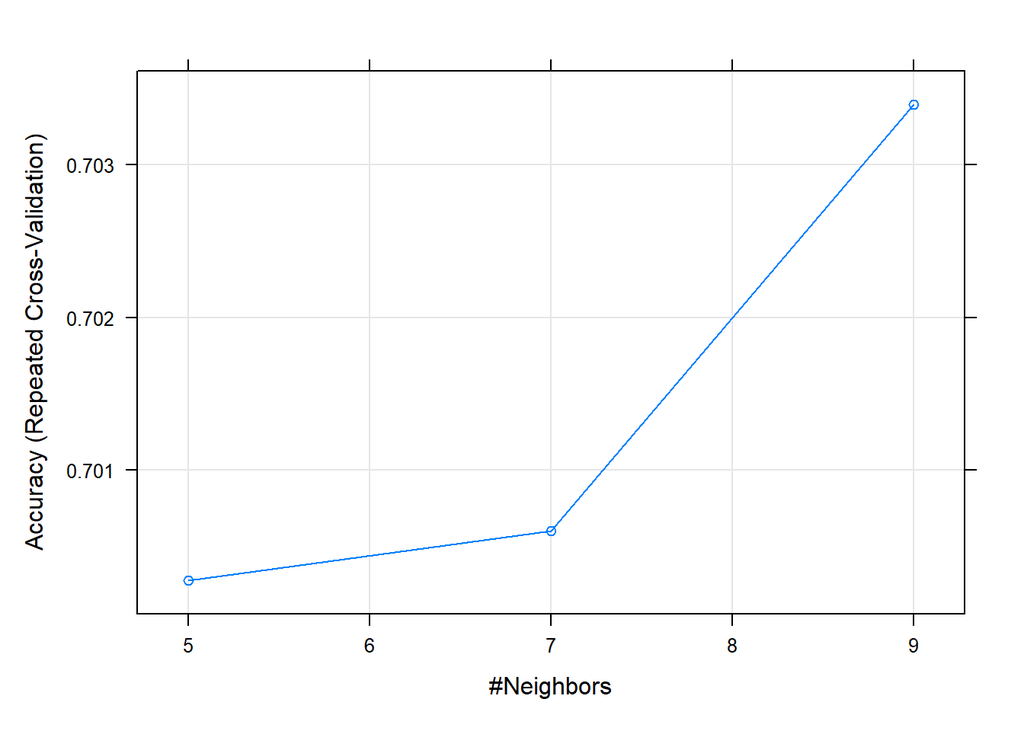

```
## Confusion Matrix and Statistics
##
##           Reference
## Prediction  -1   1
##         -1  47  54
##         1  250 664
##
##                Accuracy : 0.7005
##                  95% CI : (0.6713, 0.7285)
##     No Information Rate : 0.7074
##     P-Value [Acc > NIR] : 0.6988
##
##                   Kappa : 0.103
##
##  Mcnemar's Test P-Value : <2e-16
##
##             Sensitivity : 0.15825
##             Specificity : 0.92479
##          Pos Pred Value : 0.46535
##          Neg Pred Value : 0.72648
##              Prevalence : 0.29261
##          Detection Rate : 0.04631
##    Detection Prevalence : 0.09951
##       Balanced Accuracy : 0.54152
##
##        'Positive' Class : -1
##
```

These are predictions on the subset, not the true test data, in order to draw deeper conclusions about the homogeneity of the model upon the use of the class presented test data.

This is a confusion matrix, that depicts Predicted and Observed values in a True False manner with criteria such as True Negative, True Positive, False Positive and False Negative, thus putting a rather tough prediction into a nicely understandable table.

### Discussion and Final Model Prediction Performance

An important detail I must add, is that I did add the gender column to the test data set (it is = 1 meaning all mice are female), as I have done for the train data set, in order to use my hypothesis of gender as a factor towards the test set.

```
## Confusion Matrix and Statistics
##
##           Reference
## Prediction -1  1
##         -1 22 46
##         1  33 99
##
##                Accuracy : 0.605
##                  95% CI : (0.5336, 0.6732)
##     No Information Rate : 0.725
##     P-Value [Acc > NIR] : 0.9999
##
##                   Kappa : 0.0771
##
##  Mcnemar's Test P-Value : 0.1770
##
##             Sensitivity : 0.4000
##             Specificity : 0.6828
##          Pos Pred Value : 0.3235
##          Neg Pred Value : 0.7500
##              Prevalence : 0.2750
##          Detection Rate : 0.1100
##    Detection Prevalence : 0.3400
##       Balanced Accuracy : 0.5414
##
##        'Positive' Class : -1
##
```

### Conclussion

To conclude this report I would like to say that my model did in fact better than I anticipated, as I have very low skill level and therefore confidence. My choice of modeling and clustering the data was through the KNN approach, which offered me much insight and wiggle room to play around with various fold amounts, factors for the model, and methods. A real world application of this study, and specifically the predictive model would allow humans to understand the hierarchy of visual, senstory, and choice neurons, and the intersectionality of them all. In the age of mass media and people being chronically-online, that are visual stimuli that urge us to make choices by controlling the screen, like the mice controlling the wheel, we can determine what parts of our brains are the most responsive, and find a way to predict a response/reaction out of people consuming the visual stimulus. Such can be useful for the entertainment industry, marketing teams, and even in education settings. My findings demonstrate that the intersection of gender and neurological activity yields different responses in mice, specifically due to the fact that male mice perform better with no clear choice given, whereas female mice do a better job at explicit solutions, as well as 6 brain area usage being the most optimal for a correct response. I also outlines CA1, LD, root and SSp to be the most used and predictive brain areas among the 4 mice tried. My prediction model demonstrated that the interaction effect between gender, brain areas amount, brain-spikes, and visual contract stimuli.

An area I can see myself improving is through the data mining, as I spent days and days trying to subset the data of my dream (one with specific brain areas) but I just couldn’t figure out how to go about it, therefore had to go into the modeling phase with the amount of data I was able to extract. This I am confident in, that it would improve my predictive perfomance significantly, and be more informative. Room to grow:)

### Acknowledgements

Original Publication: https://www.nature.com/articles/s41586-019-1787-x

Discusion 10, 8,7,6 notes

Lecture Sections 8,7, and 6.

Nathaniel(@150_f1) on Piazza for Appendix Code Help

ggplot cheat sheet: https://lscholtus.gitlab.io/mosaicdata/ggplot2-cheatsheet-2.0.pdf

KNN guide : https://rpubs.com/pmtam/knn

Mice Brain Abbreviation Lists: https://www.cell.com/cms/10.1016/j.cell.2014.02.023/attachment/55cf98f6-9b54-4ba9-b8eb-a3da4bc5c345/mmc2

https://www.ncbi.nlm.nih.gov/pmc/articles/PMC6741242/

Column Formatting Guide: https://sparkbyexamples.com/r-programming/add-column-to-dataframe-in-r/?utm_content=expand_article

For Loop Appending: https://www.projectpro.io/recipes/append-output-from-for-loop-dataframe-r#:~:text=To%20store%20for%20loop%20output,the%20output%20from%20all%20iterations.

Error Fix Guide: https://www.statology.org/error-in-do_onenmeth-na-nan-inf-in-foreign-function-call/

## Appendix

```r
library(ggplot2)
library(dplyr)


session=list()
for(i in 1:18){
  session[[i]]=readRDS(paste('C:/Users/mary/OneDrive/UCD/Sophomore/STA141A/session/session',i,'.rds',sep=''))
}

session1=cbind(session[[1]]$contrast_left,session[[1]]$contrast_right,rep(1,length(session[[1]]$contrast_left)),session[[1]]$mouse_name,length(session[[1]]$brain_area),length(unique(session[[1]]$brain_area)),length(session[[1]]$spks),session[[1]]$feedback_type)

session2=cbind(session[[2]]$contrast_left,session[[2]]$contrast_right,rep(2,length(session[[2]]$contrast_left)),session[[2]]$mouse_name,length(session[[1]]$brain_area),length(unique(session[[2]]$brain_area)),length(session[[2]]$spks),session[[2]]$feedback_type)

session3=cbind(session[[3]]$contrast_left,session[[3]]$contrast_right,session[[3]]$firingrate,session[[3]]$max_firingrate,rep(3,length(session[[3]]$contrast_left)),session[[3]]$mouse_name,length(session[[1]]$brain_area),length(unique(session[[3]]$brain_area)),length(session[[3]]$spks),session[[3]]$feedback_type)

session4=cbind(session[[4]]$contrast_left,session[[4]]$contrast_right,rep(4,length(session[[4]]$contrast_left)),session[[4]]$mouse_name,length(session[[1]]$brain_area),length(unique(session[[4]]$brain_area)),length(session[[4]]$spks),session[[1]]$feedback_type)

session5=cbind(session[[5]]$contrast_left,session[[5]]$contrast_right,rep(5,length(session[[5]]$contrast_left)),session[[5]]$mouse_name,length(session[[1]]$brain_area),length(unique(session[[5]]$brain_area)),length(session[[5]]$spks),session[[5]]$feedback_type)

session6=cbind(session[[6]]$contrast_left,session[[6]]$contrast_right,session[[6]]$firingrate,session[[6]]$max_firingrate,rep(6,length(session[[6]]$contrast_left)),session[[6]]$mouse_name,length(session[[1]]$brain_area),length(unique(session[[6]]$brain_area)),length(session[[6]]$spks),session[[6]]$feedback_type)

session7=cbind(session[[7]]$contrast_left,session[[7]]$contrast_right,rep(7,length(session[[7]]$contrast_left)),session[[7]]$mouse_name,length(session[[1]]$brain_area),length(unique(session[[7]]$brain_area)),length(session[[7]]$spks),session[[7]]$feedback_type)

session8=cbind(session[[8]]$contrast_left,session[[8]]$contrast_right,rep(8,length(session[[8]]$contrast_left)),session[[8]]$mouse_name,length(session[[1]]$brain_area),length(unique(session[[8]]$brain_area)),length(session[[8]]$spks),session[[8]]$feedback_type)

session9=cbind(session[[9]]$contrast_left,session[[9]]$contrast_right,session[[9]]$firingrate,session[[9]]$max_firingrate,rep(9,length(session[[9]]$contrast_left)),session[[9]]$mouse_name,length(session[[1]]$brain_area),length(unique(session[[9]]$brain_area)),length(session[[9]]$spks),session[[9]]$feedback_type)

session10=cbind(session[[10]]$contrast_left,session[[10]]$contrast_right,rep(10,length(session[[10]]$contrast_left)),session[[10]]$mouse_name,length(session[[1]]$brain_area),length(unique(session[[10]]$brain_area)),length(session[[10]]$spks),session[[10]]$feedback_type)

session11=cbind(session[[11]]$contrast_left,session[[11]]$contrast_right,rep(11,length(session[[11]]$contrast_left)),session[[11]]$mouse_name,length(session[[1]]$brain_area),length(unique(session[[11]]$brain_area)),length(session[[11]]$spks),session[[11]]$feedback_type)

session12=cbind(session[[12]]$contrast_left,session[[12]]$contrast_right,session[[12]]$firingrate,session[[12]]$max_firingrate,rep(12,length(session[[12]]$contrast_left)),session[[12]]$mouse_name,length(session[[1]]$brain_area),length(unique(session[[12]]$brain_area)),length(session[[12]]$spks),session[[12]]$feedback_type)

session13=cbind(session[[13]]$contrast_left,session[[13]]$contrast_right,rep(13,length(session[[13]]$contrast_left)),session[[13]]$mouse_name,length(session[[1]]$brain_area),length(unique(session[[13]]$brain_area)),length(session[[13]]$spks),session[[13]]$feedback_type)

session14=cbind(session[[14]]$contrast_left,session[[14]]$contrast_right,rep(14,length(session[[14]]$contrast_left)),session[[14]]$mouse_name,length(session[[1]]$brain_area),length(unique(session[[14]]$brain_area)),length(session[[14]]$spks),session[[14]]$feedback_type)

session15=cbind(session[[15]]$contrast_left,session[[15]]$contrast_right,session[[15]]$firingrate,session[[15]]$max_firingrate,rep(15,length(session[[15]]$contrast_left)),session[[15]]$mouse_name,length(session[[1]]$brain_area),length(unique(session[[15]]$brain_area)),length(session[[15]]$spks),session[[15]]$feedback_type)

session16=cbind(session[[16]]$contrast_left,session[[16]]$contrast_right,rep(16,length(session[[16]]$contrast_left)),session[[16]]$mouse_name,length(session[[1]]$brain_area),length(unique(session[[16]]$brain_area)),length(session[[16]]$spks),session[[16]]$feedback_type)

session17=cbind(session[[17]]$contrast_left,session[[17]]$contrast_right,rep(17,length(session[[17]]$contrast_left)),session[[17]]$mouse_name,length(session[[1]]$brain_area),length(unique(session[[17]]$brain_area)),length(session[[17]]$spks),session[[17]]$feedback_type)

session18=cbind(session[[18]]$contrast_left,session[[18]]$contrast_right,session[[18]]$firingrate,session[[18]]$max_firingrate,rep(18,length(session[[18]]$contrast_left)),session[[18]]$mouse_name,length(session[[1]]$brain_area),length(unique(session[[18]]$brain_area)),length(session[[18]]$spks),session[[18]]$feedback_type)

df = rbind(session1, session2, session3,session4,session5,session6,session7,session8,session9,session10,session11,session12,session13,session14,session15,session16,session17,session18)
colnames(df) = c("contrast_left","contrast_right", "session","mouse","number_of_neurons","brain_area","spks", "feedback_type")
df = as.data.frame(df)
df$contrast_left = as.factor(df$contrast_left)
df$contrast_right = as.factor(df$contrast_right)
df$session = as.factor (df$session)
df$mouse = as.factor(df$mouse)
df$feedback_type = as.factor(df$feedback_type)

df = df[,1:8]

df = df %>% mutate(gender = factor(" ", level = c("1","0")))
female_names <- c('Cori', 'Lederberg')
male_names <- c('Forssmann', 'Hench')
```

```r
df <- df %>% mutate(gender = ifelse(mouse %in% male_names, "0", "1"))
df$gender = as.factor(df$gender)


cori.f = df %>% filter(mouse == "Cori")


forssmann.m = df %>% filter(mouse == "Forssmann")


hench.m = df %>% filter(mouse == "Hench")


lederberg.f = df%>% filter(mouse == "Lederberg")



cori.f.left = cori.f %>% filter(as.numeric(contrast_left) > as.numeric(contrast_right))
cori.f.right = cori.f %>% filter(as.numeric(contrast_right) > as.numeric(contrast_left))
cori.f.two = cori.f %>% filter(as.numeric(contrast_left)==as.numeric(contrast_right))
cori.f.same = cori.f.two %>% filter(contrast_right != 0)
cori.f.none = cori.f.two %>% filter(contrast_left == 0)


forssmann.m.left = forssmann.m %>% filter(as.numeric(contrast_left) > as.numeric(contrast_right))
forssmann.m.right = forssmann.m %>% filter(as.numeric(contrast_right) > as.numeric(contrast_left))
forssmann.m.two = forssmann.m %>% filter(as.numeric(contrast_left)==as.numeric(contrast_right))
forssmann.m.same = forssmann.m.two %>% filter(contrast_right != 0)
forssmann.m.none = forssmann.m.two %>% filter(contrast_left == 0)


hench.m.left = hench.m %>% filter(as.numeric(contrast_left) > as.numeric(contrast_right))
hench.m.right = hench.m %>% filter(as.numeric(contrast_right) > as.numeric(contrast_left))
hench.m.two = hench.m %>% filter(as.numeric(contrast_left)==as.numeric(contrast_right))
hench.m.same = hench.m.two %>% filter(contrast_right != 0)
hench.m.none = hench.m.two %>% filter(contrast_left == 0)


lederberg.f.left = lederberg.f %>% filter(as.numeric(contrast_left) > as.numeric(contrast_right))
lederberg.f.right = lederberg.f %>% filter(as.numeric(contrast_right) > as.numeric(contrast_left))
lederberg.f.two = lederberg.f %>% filter(as.numeric(contrast_left)==as.numeric(contrast_right))
lederberg.f.same = lederberg.f.two %>% filter(contrast_right != 0)
lederberg.f.none = lederberg.f.two %>% filter(contrast_left == 0)


fem = rbind(cori.f,lederberg.f)
fem.left = rbind(cori.f.left, lederberg.f.left)
fem.right = rbind(cori.f.right, lederberg.f.right)
fem.same = rbind(cori.f.same, lederberg.f.same)
fem.none = rbind(cori.f.none, lederberg.f.none)


male = rbind(forssmann.m, hench.m)
male.left = rbind(forssmann.m.left,hench.m.left)
male.right = rbind(forssmann.m.right,hench.m.right)
male.same = rbind(forssmann.m.same,hench.m.same)
male.none = rbind(forssmann.m.none,hench.m.none)

fem.correct = fem %>% filter(feedback_type == 1)
fem.incorrect = fem %>% filter(feedback_type != 1)
male.correct = male %>% filter(feedback_type == 1)
male.incorrect = male %>% filter(feedback_type != 1)


n.session=length(session)

meta <- tibble(
  mouse_name = rep('name',n.session),
  date_exp =rep('dt',n.session),
  n_brain_area = rep(0,n.session),
  n_neurons = rep(0,n.session),
  n_trials = rep(0,n.session),
  success_rate = rep(0,n.session)
)


for(i in 1:n.session){
  tmp = session[[i]];
  meta[i,1]=tmp$mouse_name;
  meta[i,2]=tmp$date_exp;
  meta[i,3]=length(unique(tmp$brain_area));
  meta[i,4]=dim(tmp$spks[[1]])[1];
  meta[i,5]=length(tmp$feedback_type);
  meta[i,6]=mean(tmp$feedback_type+1)/2;
}
 library(knitr)

kable(meta[,-2], format = "html", table.attr = "class='table table-striped'",digits=2)

ggplot(data=meta, mapping= aes(x = n_neurons, y = success_rate, col = as.factor(n_brain_area))) + geom_point() + ggtitle("Number of Neurons and Success Rate")+ xlab('Number of Neurons') + ylab("Success rate")
summary(meta[,3])
ggplot(data = fem, mapping = aes(x = feedback_type, y = brain_area, color = as.factor(session))) + geom_count() + ggtitle("Female Mice ")+ xlab('Feedback Type') + ylab("Brain Area")

ggplot(data = male, mapping = aes(x = feedback_type, y = brain_area, color = as.factor(session))) + geom_count() + ggtitle("Male Mice ")+ xlab('Feedback Type') + ylab("Brain Area")
ggplot(data = df, mapping = aes(x = feedback_type, y = gender)) + geom_count() + ggtitle("Gender and Feedback Type ")+ xlab('Feedback Type') + ylab("Gender")
ggplot(data = fem.right, mapping = aes(x = feedback_type, y = brain_area, color = as.factor(session))) + geom_count() + ggtitle("Female Mice \n Right Stimuli")+ xlab('Feedback Type') + ylab("Brain Area")

ggplot(data = male.right, mapping = aes(x = feedback_type, y = brain_area, color = as.factor(session))) + geom_count() + ggtitle("Male Mice \n Right Stimuli")+ xlab('Feedback Type') + ylab("Brain Area")

ggplot(data = fem.left, mapping = aes(x = feedback_type, y = brain_area, color = as.factor(session))) + geom_count() + ggtitle("Female Mice \n Left Stimuli")+ xlab('Feedback Type') + ylab("Brain Area")

ggplot(data = male.left, mapping = aes(x = feedback_type, y = brain_area, color = as.factor(session))) + geom_count() + ggtitle("Male Mice \n Left Stimuli")+ xlab('Feedback Type') + ylab("Brain Area")

ggplot(data = fem.same, mapping = aes(x = feedback_type, y = brain_area, color = as.factor(session))) + geom_count() + ggtitle("Female Mice \n Same(non-zero) Stimuli")+ xlab('Feedback Type') + ylab("Brain Area")

ggplot(data = male.same, mapping = aes(x = feedback_type, y = brain_area, color = as.factor(session))) + geom_count() + ggtitle("Male Mice \n Same(non-zero) Stimuli")+ xlab('Feedback Type') + ylab("Brain Area")

ggplot(data = fem.none, mapping = aes(x = feedback_type, y = brain_area, color = as.factor(session))) + geom_count() + ggtitle("Female Mice \n Zero Stimuli")+ xlab('Feedback Type') + ylab("Brain Area")

ggplot(data = male.none, mapping = aes(x = feedback_type, y = brain_area, color = as.factor(session))) + geom_count() + ggtitle("Male Mice \n Zero Stimuli")+ xlab('Feedback Type') + ylab("Brain Area")
i.s=2

i.t=44

spk.trial = session[[i.s]]$spks[[i.t]]
area=session[[i.s]]$brain_area
spk.count=apply(spk.trial,1,sum)
spk.average.tapply=tapply(spk.count, area, mean)

tmp <- data.frame(
  area = area,
  spikes = spk.count
)
spk.average.dplyr =tmp %>%
  group_by(area) %>%
  summarize(mean= mean(spikes))
average_spike_area<-function(i.t,this_session){
  spk.trial = this_session$spks[[i.t]]
  area= this_session$brain_area
  spk.count=apply(spk.trial,1,sum)
  spk.average.tapply=tapply(spk.count, area, mean)
  return(spk.average.tapply)
  }
average_spike_area(1,this_session = session[[i.s]])
```

```r
n.trial=length(session[[i.s]]$feedback_type)
n.area=length(unique(session[[i.s]]$brain_area ))



trial.summary =matrix(nrow=n.trial,ncol= n.area+1+2+1)
for(i.t in 1:n.trial){
  trial.summary[i.t,]=c(average_spike_area(i.t,this_session = session[[i.s]]),
                          session[[i.s]]$feedback_type[i.t],
                        session[[i.s]]$contrast_left[i.t],
                        session[[i.s]]$contrast_right[i.s],
                        i.t)
}

colnames(trial.summary)=c(names(average_spike_area(i.t,this_session = session[[i.s]])), 'feedback', 'left contr.','right contr.','id' )

# Turning it into a data frame
trial.summary <- as_tibble(trial.summary)

area.col=rainbow(n=n.area,alpha=0.7)
# In base R, I usually initiate a blank plot before drawing anything on it
plot(x=1,y=0, col='white',xlim=c(0,n.trial),ylim=c(0.5,2.2), xlab="Trials",ylab="Average spike counts", main=paste("Spikes per area in Session", i.s))


for(i in 1:n.area){
  lines(y=trial.summary[[i]],x=trial.summary$id,col=area.col[i],lty=2,lwd=1)
  lines(smooth.spline(trial.summary$id, trial.summary[[i]]),col=area.col[i],lwd=3)
  }
legend("topright",
  legend = colnames(trial.summary)[1:n.area],
  col = area.col,
  lty = 1,
  cex = 0.8
)

i.s=6

i.t=196

spk.trial = session[[i.s]]$spks[[i.t]]
area=session[[i.s]]$brain_area
spk.count=apply(spk.trial,1,sum)
spk.average.tapply=tapply(spk.count, area, mean)

tmp <- data.frame(
  area = area,
  spikes = spk.count
)
spk.average.dplyr =tmp %>%
  group_by(area) %>%
  summarize(mean= mean(spikes))
average_spike_area<-function(i.t,this_session){
  spk.trial = this_session$spks[[i.t]]
  area= this_session$brain_area
  spk.count=apply(spk.trial,1,sum)
  spk.average.tapply=tapply(spk.count, area, mean)
  return(spk.average.tapply)
  }
average_spike_area(1,this_session = session[[i.s]])
n.trial=length(session[[i.s]]$feedback_type)
n.area=length(unique(session[[i.s]]$brain_area ))
# Alternatively, you can extract these information in the meta that we created before.

# We will create a data frame that contain the average spike counts for each area, feedback type,  the two contrasts, and the trial id

trial.summary =matrix(nrow=n.trial,ncol= n.area+1+2+1)
for(i.t in 1:n.trial){
  trial.summary[i.t,]=c(average_spike_area(i.t,this_session = session[[i.s]]),
                          session[[i.s]]$feedback_type[i.t],
                        session[[i.s]]$contrast_left[i.t],
                        session[[i.s]]$contrast_right[i.s],
                        i.t)
}

colnames(trial.summary)=c(names(average_spike_area(i.t,this_session = session[[i.s]])), 'feedback', 'left contr.','right contr.','id' )

# Turning it into a data frame
trial.summary <- as_tibble(trial.summary)

area.col=rainbow(n=n.area,alpha=0.7)
# In base R, I usually initiate a blank plot before drawing anything on it
plot(x=1,y=0, col='white',xlim=c(0,n.trial),ylim=c(0.5,2.2), xlab="Trials",ylab="Average spike counts", main=paste("Spikes per area in Session", i.s))


for(i in 1:n.area){
  lines(y=trial.summary[[i]],x=trial.summary$id,col=area.col[i],lty=2,lwd=1)
  lines(smooth.spline(trial.summary$id, trial.summary[[i]]),col=area.col[i],lwd=3)
  }
legend("topright",
  legend = colnames(trial.summary)[1:n.area],
  col = area.col,
  lty = 1,
  cex = 0.8
)


i.s=7

i.t=50

spk.trial = session[[i.s]]$spks[[i.t]]
area=session[[i.s]]$brain_area
spk.count=apply(spk.trial,1,sum)
spk.average.tapply=tapply(spk.count, area, mean)

tmp <- data.frame(
  area = area,
  spikes = spk.count
)
spk.average.dplyr =tmp %>%
  group_by(area) %>%
  summarize(mean= mean(spikes))
average_spike_area<-function(i.t,this_session){
  spk.trial = this_session$spks[[i.t]]
  area= this_session$brain_area
  spk.count=apply(spk.trial,1,sum)
  spk.average.tapply=tapply(spk.count, area, mean)
  return(spk.average.tapply)
  }
average_spike_area(1,this_session = session[[i.s]])

n.trial=length(session[[i.s]]$feedback_type)
n.area=length(unique(session[[i.s]]$brain_area ))
# Alternatively, you can extract these information in the meta that we created before.

# We will create a data frame that contain the average spike counts for each area, feedback type,  the two contrasts, and the trial id

trial.summary =matrix(nrow=n.trial,ncol= n.area+1+2+1)
for(i.t in 1:n.trial){
  trial.summary[i.t,]=c(average_spike_area(i.t,this_session = session[[i.s]]),
                          session[[i.s]]$feedback_type[i.t],
                        session[[i.s]]$contrast_left[i.t],
                        session[[i.s]]$contrast_right[i.s],
                        i.t)
}

colnames(trial.summary)=c(names(average_spike_area(i.t,this_session = session[[i.s]])), 'feedback', 'left contr.','right contr.','id' )

# Turning it into a data frame
trial.summary <- as_tibble(trial.summary)

area.col=rainbow(n=n.area,alpha=0.7)
# In base R, I usually initiate a blank plot before drawing anything on it
plot(x=1,y=0, col='white',xlim=c(0,n.trial),ylim=c(0.5,2.2), xlab="Trials",ylab="Average spike counts", main=paste("Spikes per area in Session", i.s))


for(i in 1:n.area){
  lines(y=trial.summary[[i]],x=trial.summary$id,col=area.col[i],lty=2,lwd=1)
  lines(smooth.spline(trial.summary$id, trial.summary[[i]]),col=area.col[i],lwd=3)
  }
legend("topright",
  legend = colnames(trial.summary)[1:n.area],
  col = area.col,
  lty = 1,
  cex = 0.8
)
i.s=11

i.t=248

spk.trial = session[[i.s]]$spks[[i.t]]
area=session[[i.s]]$brain_area
spk.count=apply(spk.trial,1,sum)
spk.average.tapply=tapply(spk.count, area, mean)

tmp <- data.frame(
  area = area,
  spikes = spk.count
)
spk.average.dplyr =tmp %>%
  group_by(area) %>%
  summarize(mean= mean(spikes))
average_spike_area<-function(i.t,this_session){
  spk.trial = this_session$spks[[i.t]]
  area= this_session$brain_area
  spk.count=apply(spk.trial,1,sum)
  spk.average.tapply=tapply(spk.count, area, mean)
  return(spk.average.tapply)
  }
average_spike_area(1,this_session = session[[i.s]])

n.trial=length(session[[i.s]]$feedback_type)
n.area=length(unique(session[[i.s]]$brain_area ))
# Alternatively, you can extract these information in the meta that we created before.
```

```r
# We will create a data frame that contain the average spike counts for each area, feedback type,  the two contrasts, and the trial id

trial.summary =matrix(nrow=n.trial,ncol= n.area+1+2+1)
for(i.t in 1:n.trial){
  trial.summary[i.t,]=c(average_spike_area(i.t,this_session = session[[i.s]]),
                          session[[i.s]]$feedback_type[i.t],
                        session[[i.s]]$contrast_left[i.t],
                        session[[i.s]]$contrast_right[i.s],
                        i.t)
}

colnames(trial.summary)=c(names(average_spike_area(i.t,this_session = session[[i.s]])), 'feedback', 'left contr.','right contr.','id' )

# Turning it into a data frame
trial.summary <- as_tibble(trial.summary)

area.col=rainbow(n=n.area,alpha=0.7)
# In base R, I usually initiate a blank plot before drawing anything on it
plot(x=1,y=0, col='white',xlim=c(0,n.trial),ylim=c(0.5,2.2), xlab="Trials",ylab="Average spike counts", main=paste("Spikes per area in Session", i.s))


for(i in 1:n.area){
  lines(y=trial.summary[[i]],x=trial.summary$id,col=area.col[i],lty=2,lwd=1)
  lines(smooth.spline(trial.summary$id, trial.summary[[i]]),col=area.col[i],lwd=3)
  }
legend("topright",
  legend = colnames(trial.summary)[1:n.area],
  col = area.col,
  lty = 1,
  cex = 0.8
)
i.s=16

i.t=171

spk.trial = session[[i.s]]$spks[[i.t]]
area=session[[i.s]]$brain_area
spk.count=apply(spk.trial,1,sum)
spk.average.tapply=tapply(spk.count, area, mean)

tmp <- data.frame(
  area = area,
  spikes = spk.count
)
spk.average.dplyr =tmp %>%
  group_by(area) %>%
  summarize(mean= mean(spikes))
average_spike_area<-function(i.t,this_session){
  spk.trial = this_session$spks[[i.t]]
  area= this_session$brain_area
  spk.count=apply(spk.trial,1,sum)
  spk.average.tapply=tapply(spk.count, area, mean)
  return(spk.average.tapply)
  }
average_spike_area(1,this_session = session[[i.s]])

n.trial=length(session[[i.s]]$feedback_type)
n.area=length(unique(session[[i.s]]$brain_area ))
# Alternatively, you can extract these information in the meta that we created before.

# We will create a data frame that contain the average spike counts for each area, feedback type,  the two contrasts, and the trial id

trial.summary =matrix(nrow=n.trial,ncol= n.area+1+2+1)
for(i.t in 1:n.trial){
  trial.summary[i.t,]=c(average_spike_area(i.t,this_session = session[[i.s]]),
                          session[[i.s]]$feedback_type[i.t],
                        session[[i.s]]$contrast_left[i.t],
                        session[[i.s]]$contrast_right[i.s],
                        i.t)
}

colnames(trial.summary)=c(names(average_spike_area(i.t,this_session = session[[i.s]])), 'feedback', 'left contr.','right contr.','id' )

# Turning it into a data frame
trial.summary <- as_tibble(trial.summary)

area.col=rainbow(n=n.area,alpha=0.7)
# In base R, I usually initiate a blank plot before drawing anything on it
plot(x=1,y=0, col='white',xlim=c(0,n.trial),ylim=c(0.5,2.2), xlab="Trials",ylab="Average spike counts", main=paste("Spikes per area in Session", i.s))


for(i in 1:n.area){
  lines(y=trial.summary[[i]],x=trial.summary$id,col=area.col[i],lty=2,lwd=1)
  lines(smooth.spline(trial.summary$id, trial.summary[[i]]),col=area.col[i],lwd=3)
  }
legend("topright",
  legend = colnames(trial.summary)[1:n.area],
  col = area.col,
  lty = 1,
  cex = 0.8
)

i.s=17

i.t=82

spk.trial = session[[i.s]]$spks[[i.t]]
area=session[[i.s]]$brain_area
spk.count=apply(spk.trial,1,sum)
spk.average.tapply=tapply(spk.count, area, mean)

tmp <- data.frame(
  area = area,
  spikes = spk.count
)
spk.average.dplyr =tmp %>%
  group_by(area) %>%
  summarize(mean= mean(spikes))
average_spike_area<-function(i.t,this_session){
  spk.trial = this_session$spks[[i.t]]
  area= this_session$brain_area
  spk.count=apply(spk.trial,1,sum)
  spk.average.tapply=tapply(spk.count, area, mean)
  return(spk.average.tapply)
  }
average_spike_area(1,this_session = session[[i.s]])
n.trial=length(session[[i.s]]$feedback_type)
n.area=length(unique(session[[i.s]]$brain_area ))
# Alternatively, you can extract these information in the meta that we created before.

# We will create a data frame that contain the average spike counts for each area, feedback type,  the two contrasts, and the trial id

trial.summary =matrix(nrow=n.trial,ncol= n.area+1+2+1)
for(i.t in 1:n.trial){
  trial.summary[i.t,]=c(average_spike_area(i.t,this_session = session[[i.s]]),
                          session[[i.s]]$feedback_type[i.t],
                        session[[i.s]]$contrast_left[i.t],
                        session[[i.s]]$contrast_right[i.s],
                        i.t)
}

colnames(trial.summary)=c(names(average_spike_area(i.t,this_session = session[[i.s]])), 'feedback', 'left contr.','right contr.','id' )

# Turning it into a data frame
trial.summary <- as_tibble(trial.summary)

area.col=rainbow(n=n.area,alpha=0.7)
# In base R, I usually initiate a blank plot before drawing anything on it
plot(x=1,y=0, col='white',xlim=c(0,n.trial),ylim=c(0.5,2.2), xlab="Trials",ylab="Average spike counts", main=paste("Spikes per area in Session", i.s))


for(i in 1:n.area){
  lines(y=trial.summary[[i]],x=trial.summary$id,col=area.col[i],lty=2,lwd=1)
  lines(smooth.spline(trial.summary$id, trial.summary[[i]]),col=area.col[i],lwd=3)
  }
legend("topright",
  legend = colnames(trial.summary)[1:n.area],
  col = area.col,
  lty = 1,
  cex = 0.8
)
library("caret")

set.seed(555)

trainit = createDataPartition(df$feedback_type, p = 0.80, list = FALSE)
train <- df[trainit,]
test1 <- df[-trainit,]



trainControl = trainControl(method = "repeatedcv", number = 10, repeats = 3)
metric = "Accuracy"

set.seed(111)
my.knn = train(feedback_type ~ brain_area + gender + as.numeric(spks) + contrast_right+ contrast_left, data =train, method = "knn",
               metric = metric,
               trControl = trainControl
               )

knn.k1 = my.knn$bestTune

print(my.knn)

plot(my.knn)

set.seed(767)
pred = predict(my.knn, newdata = test1)
conf = confusionMatrix(pred,test1$feedback_type)
print(conf)
test=list()
for(i in 1:2){
  test[[i]]=readRDS(paste('C:/Users/mary/OneDrive/UCD/Sophomore/STA141A/test',i,'.rds',sep=''))
}
```

```r
test.1=cbind(test[[1]]$contrast_left,test[[1]]$contrast_right,rep(1,length(test[[1]]$contrast_left)),test[[1]]$mouse_name,length(test[[1]]$brain_area),length(unique(test[[1]]$brain_area)),length(test[[1]]$spks),test[[1]]$feedback_type)

test.2=cbind(test[[2]]$contrast_left,test[[2]]$contrast_right,rep(2,length(test[[2]]$contrast_left)),test[[2]]$mouse_name,length(test[[1]]$brain_area),length(unique(test[[2]]$brain_area)),length(test[[2]]$spks),test[[2]]$feedback_type)


test.df = rbind(test.1, test.2)
colnames(test.df) = c("contrast_left","contrast_right", "session","mouse","number_of_neurons","brain_area","spks", "feedback_type")
test.df = as.data.frame(test.df)
test.df$contrast_left = as.factor(test.df$contrast_left)
test.df$contrast_right = as.factor(test.df$contrast_right)
test.df$session = as.factor (test.df$session)
test.df$mouse = as.factor(test.df$mouse)
test.df$feedback_type = as.factor(test.df$feedback_type)

test.df = test.df %>% mutate(gender = factor(" ", level = c("1","0")))
female_name <- c('Cori', 'Lederberg')
male_name <- c('Forssmann', 'Hench')

test.df <- test.df %>% mutate(gender = ifelse(mouse %in% male_name, "0", "1"))
test.df$gender = as.factor(test.df$gender)


set.seed(299)
pred = predict(my.knn, newdata = test.df)
conf = confusionMatrix(pred,test.df$feedback_type)
print(conf)
library(sessioninfo)
sessioninfo::session_info()
```

### Session Info

```r
library(sessioninfo)
```